# MTH wordcloud

Libraries:

```r
# Some tips from Sisk:
# https://github.com/msisk1/MtH_NLP/blob/main/MtH_2026.qmd

library(tidyverse)
library(tibble)
library(tidytext)
library(textstem)
library(ggrepel)
library(ggwordcloud)
library(igraph)
library(ggraph)
library(hunspell)
library(text2vec)
library(reticulate)
library(udpipe)
library(data.table)
library(jsonlite)
library(tinytable)

seed <- 3256L
set.seed(seed)

source("functions.R")
```

Stop words: comparing different approaches: * Different stop word lists * Parts of speech

Retain words from the stop word lists that are actually informative and add a few new stop words.

```r
retain <- c(
  "man",
  "men",
  "group",
  "groups",
  "grouping",
  "grouped",
  "work",
  "works",
  "working",
  "worked",
  "area",
  "areas",
  "system",
  "systems",
  "case",
  "cases",
  "young",
  "old",
  "sex",
  "pleistocene",
  "kin",
  "band",
  "niche",
  "wive",
  "inland",
  "economy",
  "infanticide",
  "gather",
  "equilibrium",
  "information"
)

new_stop_words <- c(
  "pp",
  "set",
  "call",
  "chapter",
  "volume"
)

stop_words_iso <-
  tibble(
    word = stopwords::stopwords('en', source = "stopwords-iso"),
    lexicon = "iso"
  )

stop_words2 <-
  stop_words |>
  dplyr::filter(lexicon != "onix")

# Using stop_words_iso for now
STOPWORDS <-
  # stop_words2 |>
  stop_words_iso |>
  filter(!word %in% retain) |>
  add_row(
    word = new_stop_words,
    lexicon = "Added"
  )
```

Load the text from the internet or a saved version, tokenize and lemmatize

```r
# Get text version of MTH from Internet Archive
# Different formats: https://archive.org/download/ManTheHunter

if (!file.exists("man-the-hunter.txt")) {
  mth_raw <- read_lines(
    "https://archive.org/download/ManTheHunter/Man%20the%20Hunter_djvu.txt"
  )
  write_lines(mth_raw, file = "man-the-hunter.txt")
} else {
  mth_raw <- read_lines("man-the-hunter.txt")
}

# Remove frontmatter, and references
preface <- 75
main_text_start <- 746
references <- 36991
mth0 <-
  mth_raw[main_text_start:references] |>
  str_replace_all("‘|’", "'") |>
  str_replace_all("“|”", '"') |>
  str_replace_all("/", " ") |>
  str_squish() |>
  # Remove the volume title, mentioned throughout
  # the text, per discussion with Sisk
  str_replace_all(regex("Man the Hunter", ignore_case = T), "MTH")

# Remove running titles for the same reason
source("running_titles.R") # Character vector of running titles

for (running_title in running_titles) {
  rx <- paste0("^\\d*\\s*", running_title)
  mth0 <- mth0[!str_detect(mth0, regex(rx, ignore_case = T))]
}

# Try to fix words hyphenated
# at the end of lines. See functions.R
mth <-
  str_flatten(mth0, " ") |>
  str_replace_all("\\d+", "") |>
  str_squish() |>
  str_replace_all("- ", "-") |>
  str_split_1(" ") |>
  dehyphenate() |>
  str_flatten(" ") |>

  # Some manual fixes
  str_replace_all("ofarcheological", "of archeological") |>
  str_replace_all("archeo", "archaeo") |>
  str_replace_all("Archeo", "Archaeo") |>
  str_replace_all("per cent", "percent") |>
  str_replace_all("wor ld", "world") |>
  str_replace_all("IKung", "!Kung") |>
  str_replace_all("Turn-bull", "Turnbull") |>
  str_replace_all("Wood-burn", "Woodburn") |>
  str_replace_all("Wash-burn", "Washburn") |>
  str_replace_all(
    regex("hunters and gatherers", ignore_case = T),
    "hunter-gatherer"
  )

# Needed later for spaCy lemmatizer
mth_length <- str_count(mth) + 10

# Tokenizer and lemmatizer using a model that retains hyphenated words
ud_model <- udpipe_load_model(file = "english-gum-ud-2.5-191206.udpipe")
out_udpipe <- udpipe(mth, ud_model)
```

Check if any common stop words are important and should be removed from the stopword list. There is a subtle complication: some stop words, like “better”, are lemmatized into lemmas, like “good”, that are not stop words.

```r
# lemmas in stop words
sort(
  table(out_udpipe$lemma[str_to_lower(out_udpipe$lemma) %in% STOPWORDS$word]),
  decreasing = T
)[1:150]
```

```
       the         of         be        and         in          a         to
     12754       9353       7666       5578       4572       4550       4252
      that       have        for         as         it       this         or
      2516       1973       1707       1549       1241       1236       1186
      with         by        not         on       they          I      which
      1181       1179       1095       1073       1021        958        847
      from         at      their        but      other         we         do
       800        740        719        686        668        656        625
       one      these        may       more      there        can       some
       623        606        594        590        558        509        504
      such       than      would        all      among       only        use
       485        480        448        435        392        391        369
   between         if         he      about         no     number      large
       364        364        352        322        320        319        311
      also        his       make       year        who         so       when
       309        309        307        307        296        285        285
      most        any       will       into        two       very       even
       276        272        265        261        260        259        255
         p       many      great       find       what       seem      where
       249        242        230        221        221        216        215
      much    however      early        its      point      small      might
       209        208        197        195        194        193        192
     those       both       same     should       take       give  important
       192        191        191        191        191        190        190
       way       each        say        out       well       site       over
       188        185        185        184        184        183        181
   example       fact       must       good       kind     within       show
       180        180        180        177        177        176        173
      part  different    suggest    present    certain      while       less
       171        169        168        164        163        163        162
       few   although   possible        see      since       know     during
       161        160        160        158        158        157        151
     first        our       mean       then    problem       high      could
       150        148        145        144        143        142        141
        my    another       long      think    because    through     become
       138        135        134        134        132        132        131
    member  available      three     appear        how       need       upon
       131        130        130        128        127        127        126
       per       like       thus        far         up        own      least
       124        123        123        122        120        119        118
    rather    perhaps      under    several   probably particular      still
       117        116        116        114        112        109        109
   without    chapter      often
       108        106        106
```

```r
# tokens (words) in stop words
sort(
  table(out_udpipe$token[str_to_lower(out_udpipe$token) %in% STOPWORDS$word]),
  decreasing = T
)[1:150]
```

```
       the         of        and         to         in          a         is
     11535       9327       5517       4250       4078       3641       2706
      that        for        are         as         be        The         or
      2490       1577       1576       1472       1402       1217       1173
        by       with       have        not         on       this         it
      1146       1141       1107       1059       1018        912        892
         I      which       from        was      their       they         at
       888        846        763        706        690        688        674
        an        one        may       were       more      other        has
       673        597        594        587        580        541        532
       but         In       been       than      these         we       some
       517        495        489        480        479        469        449
     would       such      there        can        all       only    between
       446        442        428        424        404        369        361
        It      among       This      about         do         no       also
       349        337        324        317        303        298        296
       who        his        had       will        any       into        two
       296        295        268        263        262        261        257
        he       very       most          p       many       them         so
       255        254        251        249        241        239        235
      when     number         if       even      large       much          A
       230        224        221        218        202        201        199
     where       what      might       same  important     should        use
       196        195        192        191        189        189        189
       its      those       must        out       over       both      years
       187        185        180        180        178        176        175
      well        But  different       each     within      small    certain
       171        169        169        167        167        162        160
      less   possible       fact        way        few    example         If
       159        158        154        150        146        143        143
       our      could       then    through       used      while       year
       141        138        138        132        131        131        131
 available      There      three      great      first       part    present
       130        130        130        129        128        127        127
     These       upon        did       does     during        per       made
       127        126        125        124        123        122        121
     point         up        For      least    however       like      seems
       120        120        119        118        117        117        117
     found    members         my        how      means      under    because
       115        115        115        114        112        112        111
       own       make     rather    another       long      often      still
       111        110        110        109        108        107        107
particular    several      think
       105        105        105
```

Compare stops words generated from udpip “position of speech” (pos) to the STOPWORDS list. The possible advantage of using position-of-speech is that e.g., homonyms, like good (good boy vs. an expensive good) should be treated as stop words in some cases but not others.

However, some words, like Pleistocene, are incorrectly tagged, e.g., as a NUM, and then they are incorrectly removed as a stop word. In other cases, words that should be removed as stop words don’t belong to any of these parts of speech.

```r
pos_stopwords <- c(
  "DET", # Deteriminers. e.g., the, this, a
  "PRON", # Pronouns
  "ADP", # Prepositions (in, of, to)
  "CCONJ", # conjunctions (and, but, because)
  "SCONJ",
  "AUX", # Auxiliary verbs (is, have, will)
  "PART", # particles ('s, not, to)
  "PUNCT", # Punctuation
  "SYM", # Symbols
  "NUM" # Numbers
)

stopwords_udpipe <-
  out_udpipe |>
  dplyr::filter(upos %in% pos_stopwords) |>
  mutate(lemma = str_to_lower(lemma))
```

position-of-speech potential stop words missed by list-based stop words

```r
missed1 <-
  stopwords_udpipe |>
  dplyr::filter(
    lemma %in% setdiff(lemma, STOPWORDS$word)
  )
sort(table(missed1$lemma), decreasing = T)[1:150]
```

```
          ,           .           )           (           "           ;
      11162        8338        1813        1800        1260         625
          :          's           —           ?          ''           =
        568         505         456         166         155          91
          '           *           +         ...           [           !
         76          58          45          35          28          23
          ]           ^        band           >           ■           •
         22          22          18          14          14          11
     accord    eighteen           «         sex    thirteen           %
         11          11          10          10          10           9
          £       niche       prior      regard          ..     sixteen
          7           7           7           7           6           6
       -the     complex      gather          w+           »           $
          5           5           5           5           4           4
 constitute         kin          m+         na)         nb) pleistocene
          4           4           4           4           4           4
         .]      depend     economy equilibrium infanticide      inland
          3           3           3           3           3           3
    undergo        unit        wive          .*          .£         'he
          3           3           3           2           2           2
          §           &          •§          ``          °°         °°°
          2           2           2           2           2           2
          <          ~°         aa)     affords         aux          b)
          2           2           2           2           2           2
       bear        bind     caribou        cite     compare    comprise
          2           2           2           2           2           2
     debris     diffuse     discard    emphasis          en    evidence
          2           2           2           2           2           2
    exogamy        fall    fourteen       gross       group    hitherto
          2           2           2           2           2           2
        ioo        land         m.a        men+      moiety         nc)
          2           2           2           2           2           2
        nd)    nineteen    non-band         nut         ofa     oneself
          2           2           2           2           2           2
     onward   overshoot         p-)    polygyny          qf      seldom
          2           2           2           2           2           2
        sj)     thyself       trout       units         w+o        -his
          2           2           2           2           2           1
         —i        ,but          :§        !the          .,      'at'in
          1           1           1           1           1           1
      'hese        'hey        'his         'in          ("         (i)
          1           1           1           1           1           1
        (m)          *•        *han         •**         •in         ^nd
          1           1           1           1           1           1
         ==          >>           |          ||           ~        ~°°>
          1           1           1           1           1           1
         ■°           ▼        ♦not           ✓         aa$   abundance
          1           1           1           1           1           1
     accept    achtzehn       agree       aleut       alike  altogether
          1           1           1           1           1           1
```

List stop words missed by position-of-speech potential stop words

```r
missed2 <-
  out_udpipe |>
  dplyr::filter(
    str_to_lower(lemma) %in% setdiff(STOPWORDS$word, stopwords_udpipe$lemma)
  )
sort(table(missed2$lemma), decreasing = T)[1:150]
```

```
       other         more       number        large         make         year
         668          590          319          311          307          307
        most         even            p         many        great      however
         276          255          249          242          230          208
       early        small         same         take         give    important
         197          193          191          191          190          190
         way          say         well         site      example         fact
         188          185          184          183          180          180
        good         kind         show         part    different      suggest
         177          177          173          171          169          168
     present      certain         less          few     possible          see
         164          163          162          161          160          158
        know        first         then      problem         high         long
         157          150          144          143          142          134
       think       become       member    available       appear         need
         134          131          131          130          128          127
        thus          far          own        least      perhaps      several
         123          122          119          118          116          114
    probably   particular        still      chapter        place          now
         112          109          109          106          106          105
     general     consider         move      section      similar         come
         102          100           98           98           97           95
       value     indicate     describe         here       course   importance
          95           93           91           91           87           87
   necessary        right   especially            b        state       effect
          86           86           85           84           84           80
       order       second       little          set          new         name
          79           79           77           77           74           73
  relatively       obtain       recent          low       almost        world
          72           71           71           70           69           68
     usually           pp         able        clear    generally          too
          67           66           65           65           65           65
     clearly     interest         back       likely     research       always
          64           64           63           63           63           62
     various        whole       volume    certainly         last        thing
          62           62           61           60           60           60
       allow          try        cause        never        today       amount
          58           56           54           53           53           51
     further    sometimes         keep         just            N         look
          51           51           50           48           47           46
    recently          run       useful            W  significant        again
          46           46           46           46           45           44
         ask    primarily         want particularly            c    something
          44           44           44           43           41           39
         end        means     possibly     actually         line      believe
          38           38           38           37           37           36
   elsewhere         Many       fairly      largely       really      contain
          36           35           34           34           34           32
         due         help         test         turn       widely     directly
          32           32           32           32           32           31
```

Conclusion: too many stop words missed by position-of-speech:

Remove stopwords using standard list (STOPWORDS), but matching with the original word, not the lemma, to avoid problem of stop words lemmatized into non stop words.

```r
lemmas_udpipe0 <-
  out_udpipe |>
  rename(word = token, pos = upos) |>
  mutate(
    word = str_to_lower(word),
    word = str_remove_all(word, "[^[:alnum:]-]"), #
    lemma = str_to_lower(lemma)
  ) |>
  anti_join(STOPWORDS, by = join_by(word == word))
```

Top hyphenated words

```r
lemmas_udpipe0 |>
  dplyr::filter(str_detect(lemma, "-")) |>
  summarise(N = n(), .by = lemma) |>
  arrange(desc(N)) |>
  dplyr::filter(N >= 5)
```

```
               lemma   N
1    hunter-gatherer 180
2    radcliffe-brown  70
3       levi-strauss  47
4       cross-cousin  36
5     hunting-gather  18
6        small-scale  11
7         net-hunter  11
8      hunter-gather   9
9          so-called   9
10    cross-cultural   9
11  hunter-gatherers   8
12     mother-in-law   8
13   special-purpose   8
14    niece-exchange   8
```

[output cut: 22 more lines]

Modify the `clean_lemmas` function to aggregate a few of these and then create bigrams

```r
lemmas_udpipe <-
  lemmas_udpipe0 |>
  clean_lemmas() |> # See functions.R
  mutate(
    next_lemma = txt_next(lemma),
    bigram = paste(lemma, next_lemma)
  )
```

Lemmas from spaCy using the cleaned up text `mth`

```python
import spacy

spacy.util.fix_random_seed(r.seed)
nlp = spacy.load("en_core_web_sm")
nlp.max_length = r.mth_length
doc = nlp(r.mth)
```

```r
doc2 <- iterate(py$doc)
lemmas_spacy <-
  tibble(
    word = map_chr(doc2, \(token) str_to_lower(token$text)),
    lemma = map_chr(doc2, \(token) str_to_lower(token$lemma_)),
    pos = map_chr(doc2, \(token) token$pos_)
  ) |>
  anti_join(STOPWORDS, by = join_by(word == word)) |>
  clean_lemmas()
```

Count lemmas

```r
# Count lemmas
mth_words_spacy <-
  lemmas_spacy |>
  group_by(lemma) |>
  summarise(n = n()) |>
  arrange(desc(n))

mth_words_udpipe <-
  lemmas_udpipe |>
  group_by(lemma) |>
  summarise(n = n()) |>
  arrange(desc(n))

# See functions.R
lemmas_sisk <-
  sisk_lemmas(mth0) |>
  rename(lemma = word, word = word_orig) |>
  anti_join(STOPWORDS, by = join_by(word == word))

mth_words_sisk <-
  lemmas_sisk |>
  group_by(lemma) |>
  summarise(n = n()) |>
  arrange(desc(n))
```

Identifying major discrepancies. “cent” is mostly from “per cent” in the raw text; I unified the spelling of “archaeology”, etc.; “brown” is mostly references to Radcliffe-Brown. “cross” mostly appears in the hyphentated “cross-cultural” or “cross-cousin”. The udpipe lemmatizer retains “hunter-gatherer” as a single lemma. The Sisk lemmatizer often maps “number” to “numb”, and many words to “good”. Other discrepancies were addressed by iterating parts of the pipeline many times and making corrections in the `clean_lemmas` function.

```r
mth_words_combined <-
  full_join(mth_words_spacy, mth_words_udpipe, by = 'lemma') |>
  full_join(mth_words_sisk, by = 'lemma') |>
  rename(
    n_spacy = n.x,
    n_udpipe = n.y,
    n_sisk = n
  ) |>
  rowwise() |>
  mutate(
    sd = sd(c(n_spacy, n_udpipe, n_sisk)),
    cv = sd / mean(c(n_spacy, n_udpipe, n_sisk))
  )

mth_words_discrepancies <-
  mth_words_combined |>
  dplyr::filter(
    cv > 0.25,
    n_spacy > 50 | n_udpipe > 50 | n_sisk > 50
  )

tt(arrange(mth_words_discrepancies, desc(cv)))
```

| lemma | n_spacy | n_udpipe | n_sisk | sd | cv |
| --- | --- | --- | --- | --- | --- |
| cent | 2 | 2 | 134 | 76.21024 | 1.6567443 |
| own | 13 | 8 | 53 | 24.66441 | 0.9999087 |
| archaeological | 141 | 141 | 1 | 80.82904 | 0.8568449 |
| archaeologist | 70 | 70 | 1 | 39.83717 | 0.8475993 |
| percent | 139 | 139 | 2 | 79.09699 | 0.8474677 |
| brown | 73 | 3 | 70 | 39.57693 | 0.8132246 |
| cross | 61 | 6 | 58 | 30.92464 | 0.7421913 |
| gatherer | 231 | 29 | 215 | 112.29129 | 0.7092081 |
| kung | 61 | 61 | 16 | 25.98076 | 0.5647992 |
| cousin | 60 | 18 | 57 | 23.43075 | 0.5206833 |
| dry | 60 | 52 | 20 | 21.16601 | 0.4810457 |
| aborigine | 186 | 188 | 85 | 58.89822 | 0.3849557 |
| understand | 45 | 45 | 69 | 13.85641 | 0.2614416 |

Compare frequencies of 200 most frequent words in spaCy and udpipe. Large discrepancies in hunter and gather are due, in part to the retention of the hyphenated “hunter-gatherer” in the udpipe version. Some of the biggest discrepancies were already addressed in the `clean_lemmas` function (see `functions.R`).

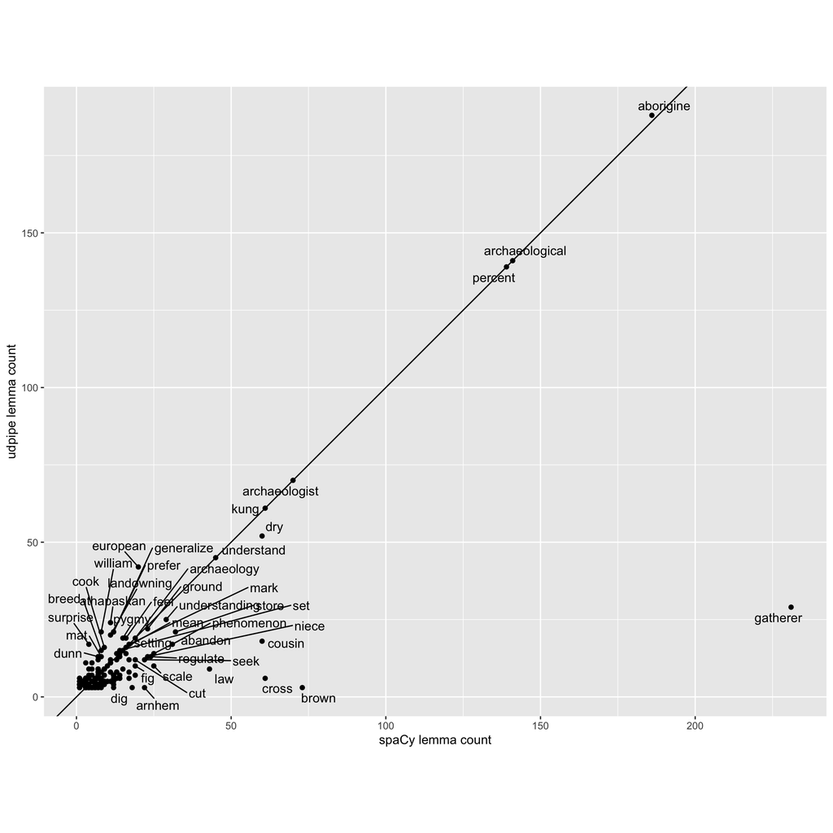

```r
d <-
  mth_words_combined |>
  dplyr::filter(!is.na(sd), cv > 0.25) |>
  arrange(desc(n_udpipe))

ggplot(d[1:200, ], aes(n_spacy, n_udpipe, label = lemma)) +
  geom_point() +
  geom_text_repel(max.overlaps = 50) +
  geom_abline(slope = 1, intercept = 0) +
  #   scale_x_log10() +
  #   scale_y_log10() +
  labs(x = "spaCy lemma count", y = "udpipe lemma count") +
  coord_fixed()
```

The Sisk lemmatizer maps “number” to “numb”, and many more words to “good” than does the udpipe lemmatizer

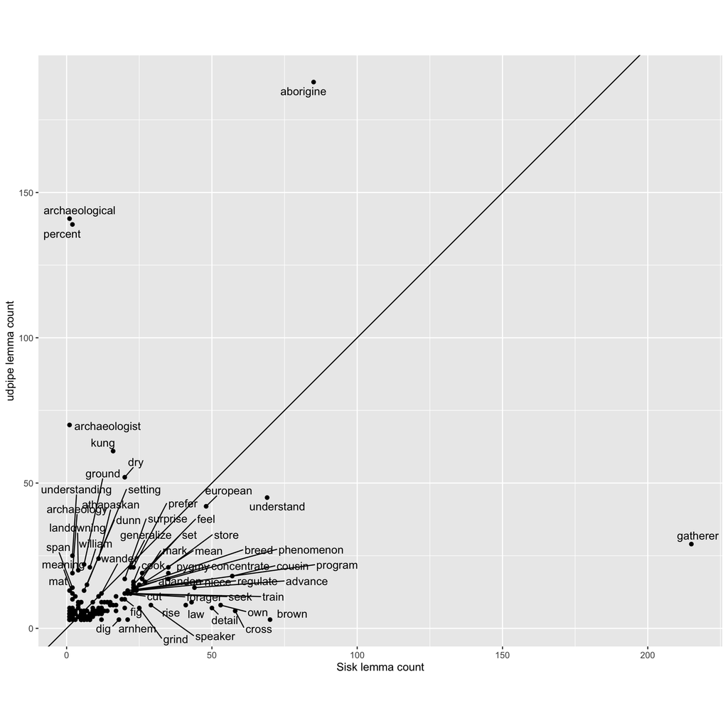

```r
ggplot(d[1:200, ], aes(n_sisk, n_udpipe, label = lemma)) +
  geom_point() +
  geom_text_repel(max.overlaps = 50) +
  geom_abline(slope = 1, intercept = 0) +
  labs(x = "Sisk lemma count", y = "udpipe lemma count") +
  coord_fixed()
```

Top bigrams

```r
sort(table(lemmas_udpipe$bigram), decreasing = T)[1:50]
```

```
            local group             hunt gather             square mile
                    115                     114                      75
    social organization      population density          vegetable food
                     71                      66                      62
            social unit             food supply    australian aborigine
                     46                      43                      40
        northwest coast          nuclear family            kung bushman
                     39                      38                      36
             field work             hunt people           person square
                     35                      35                      34
          food resource           marriage rule         population size
                     33                      33                      33
   subsistence activity              plant food           south america
                     33                      30                      30
           hunt society               man woman         tropical forest
                     29                      29                      29
             group size       ethnographic data              hunt group
                     28                      27                      27
             local band        social structure      equilibrium system
                     27                      27                      26
        human evolution            social group          kinship system
                     26                      26                      25
            male female archaeological evidence   archaeological record
                     25                      24                      24
         division labor              dry season              task group
                     24                      24                      24
           coast salish      local organization        nonhuman primate
                     23                      23                      23
          regional band           north america   cross-cousin marriage
                     23                      22                      21
       human population               hunt fish               bow arrow
                     21                      21                      20
              hunt life           landown group
                     20                      20
```

Network co-occurence

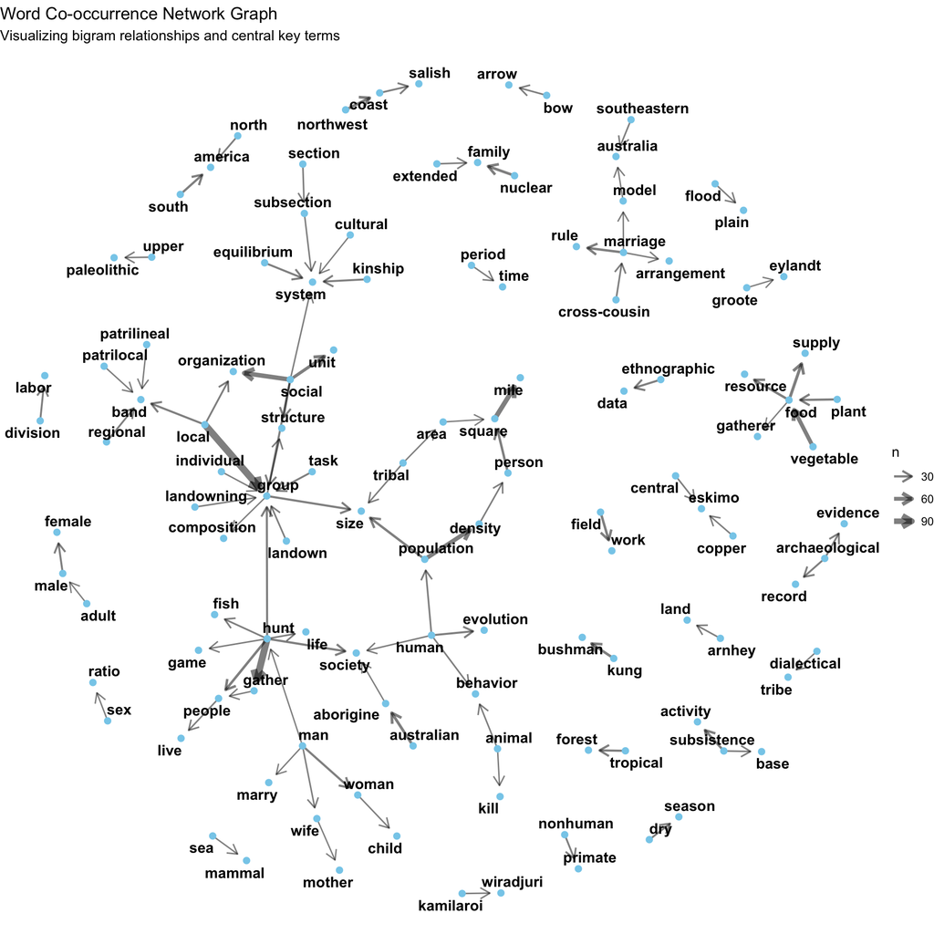

```r
bigram_graph <-
  lemmas_udpipe |>
  count(lemma, next_lemma, sort = T) |>
  dplyr::filter(n >= 15) |>
  igraph::graph_from_data_frame()

plot_graph <-
  ggraph(bigram_graph, layout = "fr") +
  # Edge width matches bigram frequency.
  geom_edge_link(
    aes(edge_width = n), # edge_alpha = n,
    edge_alpha = 0.5,
    show.legend = TRUE,
    arrow = arrow(length = unit(3, 'mm')), # Shows phrase directionality
    end_cap = circle(3, 'mm')
  ) + # Stops arrow hiding under the node text

  # Draw the nodes (individual words)
  geom_node_point(color = "skyblue", size = 2) +

  # Overlay readable text labels onto the nodes
  geom_node_text(
    aes(label = name),
    # vjust = 1.5,
    # hjust = 0.5,
    check_overlap = F,
    repel = T,
    fontface = "bold",
    size = 4
  ) +
  # scale_edge_alpha(name = "Co-occurrence Frequency") +
  scale_edge_width(range = c(0.5, 2.5)) + # , guide = "none"
  theme_void() + # Removes axes, ticks, and background grid lines
  labs(
    title = "Word Co-occurrence Network Graph",
    subtitle = "Visualizing bigram relationships and central key terms"
  )
plot_graph
```

```r
ggsave("networkgraph.pdf", plot_graph)
```

Top 200 words

```r
# Top 200 words
mth200spacy <- mth_words_spacy[1:200, ]
mth200udpipe <- mth_words_udpipe[1:200, ]
```

The basic word cloud based on udpipe lemmas:

```r
p <-
  ggplot(mth200udpipe, aes(label = lemma, size = n)) +
  geom_text_wordcloud_area(rm_outside = F, grid_size = 3, seed = 9741) +
  scale_size_area(max_size = 30) +
  theme_minimal()
fn <- "wordcloud.basic.svg"
ggsave(fn, p, width = 9, height = 9)
```

[figure not shown]

Word vectors from Wiki Giga 2024. Find vectors of top 200 words from MTH relative to a large corpus of text from Wikipedia and newswire text such as the Associated Press (AP), Agence France-Presse (AFP), The New York Times, and the Xinhua News Agency.

```r
# Word embeddings: Wiki GIGA 2024
glove_raw <- fread(
  "wiki_giga_2024_100_MFT20_vectors_seed_2024_alpha_0.75_eta_0.05.050_combined.txt",
  header = FALSE,
  data.table = FALSE,
  encoding = "UTF-8"
)
glove_words <- glove_raw[, 1]
glove_matrix <- as.matrix(glove_raw[, -1])

# Assign the words as row names for fast lookup matrices
rownames(glove_matrix) <- glove_words
rm(glove_raw)

# Vectors for top 200
# Using spaCy because glove_words does not contain "hunter-gatherer"

wikivec200 <- glove_matrix[mth200spacy$lemma, ]
rm(glove_matrix)
```

Dimension reduction for plotting

```python
import pacmap

reducer1 = pacmap.PaCMAP(
    n_components=2,  # Coordinates for 2D plotting
    distance="angular",
    apply_pca=True,
    n_neighbors=None,  # Default is 10; None: auto-selection
    MN_ratio=0.5,  # Mid-near neighbors ratio (default: 0.5)
    FP_ratio=2.0,  # Further-away pairs ratio (default: 2.0)
    lr=1.0,  # Learning rate
    num_iters=450,  # Default is 450 (100 mid, 200 far, 150 local)
    random_state=r.seed,
)
embedding1 = reducer1.fit_transform(r.wikivec200)
```

Plot

```r
mth200 <- as_tibble(wikivec200, rownames = "lemma")
mth200$n <- mth200spacy$n
mth200$x <- py$embedding1[, 1]
mth200$y <- py$embedding1[, 2]
fn <- "wordcloud.wiki.svg"
plot_vectors(mth200, fn, colorize = F)
```

[figure not shown]

text2vec using udpipe sentences as the documents:

```r
# text2vec word embeddings (GlobalVectors)
mth_udpipe <-
  lemmas_udpipe |>
  summarise(
    sentence = str_flatten(lemma, " "),
    .by = sentence_id
  )
it <- itoken(mth_udpipe$sentence)
vocab <- create_vocabulary(it)
vocab <- prune_vocabulary(vocab, term_count_min = 5L)
vectorizer <- vocab_vectorizer(vocab)
# use window of 5-10 for context words
tcm <- create_tcm(it, vectorizer, skip_grams_window = 8L)
glove <- GlobalVectors$new(rank = 30, x_max = 5)
wv_main <- glove$fit_transform(
  tcm,
  n_iter = 100,
  convergence_tol = 0.001,
  n_threads = 1
)
wv_context <- glove$components
word_vectors <- wv_main + t(wv_context)

text2vec200 <- word_vectors[mth200udpipe$lemma, ]
```

Reduce dimensionality

```python
# import pacmap

reducer2 = pacmap.PaCMAP(
    n_components=2,  # Coordinates for 2D plotting
    distance="angular",
    apply_pca=False,
    n_neighbors=None,  # Default is 10; None: auto-selection
    MN_ratio=0.5,  # Mid-near neighbors ratio (default: 0.5)
    FP_ratio=2.0,  # Further-away pairs ratio (default: 2.0)
    lr=1.0,  # Learning rate
    num_iters=450,  # Default is 450 (100 mid, 200 far, 150 local)
    random_state=r.seed,
)
embedding2 = reducer2.fit_transform(r.text2vec200)
```

Plot

```r
mth200 <- as_tibble(text2vec200, rownames = "lemma")
mth200$n <- mth200udpipe$n
mth200$x <- py$embedding2[, 1]
mth200$y <- py$embedding2[, 2]
fn <- "wordcloud.t2v.svg"
plot_vectors(mth200, fn, colorize = F)
```

[figure not shown]

Mapping the above semantic map into an ellipse to resemble a standard word cloud:

```r
source("pack_elliptical_cloud.R")
```

[figure not shown]

Hierarchical clusters

```r
source("clusters.R")
```

[figure not shown]